# Lab 01 R Learning

Pradeep Paladugula

2020-01-19

# Logical Operators:

1. Use logical operations to get R to agree that “two plus two equals 5” is FALSE.

```r
2 + 2 == 5
```

```
## [1] FALSE
```

2. Use logical operations to test whether 8 ^ 13 is less than 15 ^ 9.

```r
8^13 < 15^9
```

```
## [1] FALSE
```

# Variables:

3. Create a variable called potato whose value corresponds to the number of potatoes you’ve eaten in the last week. Or something equally ridiculous. Print out the value of potato.

```r
potato <- 6
print(potato)
```

```
## [1] 6
```

4. Calculate the square root of potato using the sqrt() function. Print out the value of potato again to verify that the value of potato hasn’t changed.

```r
sqrt(potato)
```

```
## [1] 2.44949
```

5. Reassign the value of potato to potato * 2. Print out the new value of potato to verify that it has changed.

```r
potato <- potato * 2
print(potato)
```

```
## [1] 12
```

6. Try making a character (string) variable and a logical variable . Try creating a variable with a “missing” value NA. You can call these variables whatever you would like. Use class(variablename) to make sure they are the right type of variable.

```r
charvar <- c("Pradeep", "Paladugla", "nani")
class(charvar)
```

```
## [1] "character"
```

```r
a = 1; b = 2
c <- a < b
class(c)
```

```
## [1] "logical"
```

```r
navar <- NA
class(navar)
```

```
## [1] "logical"
```

```r
navar <- c(NA, "pradeep")
class(navar)
```

```
## [1] "character"
```

```r
navar <- c(NA, 1)
class(navar)
```

```
## [1] "numeric"
```

```r
navar <- c("pradep", NA, 1)
class(navar)
```

```
## [1] "character"
```

# Vectors:

7. Create a numeric vector with three elements using c().

```r
vec <- c(1:3)
print(vec)
```

```
## [1] 1 2 3
```

8. Create a character vector with three elements using c().

```r
charvar <- c("Pradeep", "Paladugula", "nani")
print(charvar)
```

```
## [1] "Pradeep"    "Paladugula" "nani"
```

9. Create a numeric vector called age whose elements contain the ages of three people you know, where the names of each element correspond to the names of those people.

```r
ages <- c( 44, 19, 59)
names(ages) <- charvar
print(ages)
```

```
##    Pradeep Paladugula       nani
##         44         19         59
```

10. Use “indexing by number” to get R to print out the first element of one of the vectors you created in the last questions.

```r
print(ages[1])
```

```
## Pradeep
##      44
```

11. Use logical indexing to return all the ages of all people in age greater than 20.

```r
print(ages[ages > 20])
```

```
## Pradeep    nani
##      44      59
```

12. Use indexing by name to return the age of one of the people whose ages you’ve stored in age

```r
print(ages["Paladugula"])
```

```
## Paladugula
##         19
```

# Matrices:

# Dataframes:

13. Load the airquality dataset.
14. Use the $ method to print out the Wind variable in airquality.
15. Print out the third element of the Wind variable.

```r
data("airquality")
str(airquality)
```

```
## 'data.frame':    153 obs. of  6 variables:
##  $ Ozone  : int  41 36 12 18 NA 28 23 19 8 NA ...
##  $ Solar.R: int  190 118 149 313 NA NA 299 99 19 194 ...
##  $ Wind   : num  7.4 8 12.6 11.5 14.3 14.9 8.6 13.8 20.1 8.6 ...
##  $ Temp   : int  67 72 74 62 56 66 65 59 61 69 ...
##  $ Month  : int  5 5 5 5 5 5 5 5 5 5 ...
##  $ Day    : int  1 2 3 4 5 6 7 8 9 10 ...
```

```r
airwind <- airquality$Wind
print(airwind[3])
```

```
## [1] 12.6
```

16. Create a new data frame called aq that includes only the first 10 cases. Hint: typing c(1,2,3,4,5,6,7,8,9,10) is tedious. R allows you to use 1:10 as a shorthand method!
17. Use logical indexing to print out all days (ie. cases) in aq where the Ozone level was higher than 20.
    1. What did the output do with NA values?
18. Use subset() to do the same thing. Notice the difference in the output.

```r
aq <- data.frame(c(1:10))
airozone <- airquality$Ozone
print(aq[airozone > 20, ])
```

```
##   [1]  1  2 NA  6  7 NA NA NA NA NA NA NA NA NA NA NA NA NA NA NA NA NA NA NA NA
##  [26] NA NA NA NA NA NA NA NA NA NA NA NA NA NA NA NA NA NA NA NA NA NA NA NA NA
##  [51] NA NA NA NA NA NA NA NA NA NA NA NA NA NA NA NA NA NA NA NA NA NA NA NA NA
##  [76] NA NA NA NA NA NA NA NA NA NA NA NA NA NA NA NA NA NA NA NA NA NA NA NA NA
## [101] NA NA NA NA NA NA NA NA NA NA NA NA NA NA NA NA
```

```r
subset(aq, airozone > 20)
```

```
##       c.1.10.
## 1           1
## 2           2
## 6           6
## 7           7
## NA         NA
## NA.1       NA
## NA.2       NA
## NA.3       NA
## NA.4       NA
## NA.5       NA
## NA.6       NA
## NA.7       NA
## NA.8       NA
## NA.9       NA
## NA.10      NA
## NA.11      NA
## NA.12      NA
## NA.13      NA
## NA.14      NA
## NA.15      NA
## NA.16      NA
## NA.17      NA
## NA.18      NA
## NA.19      NA
## NA.20      NA
## NA.21      NA
## NA.22      NA
## NA.23      NA
## NA.24      NA
## NA.25      NA
## NA.26      NA
## NA.27      NA
## NA.28      NA
## NA.29      NA
## NA.30      NA
## NA.31      NA
## NA.32      NA
## NA.33      NA
## NA.34      NA
```

[output cut: 25 more lines]

```
## NA.60      NA
## NA.61      NA
## NA.62      NA
## NA.63      NA
## NA.64      NA
## NA.65      NA
## NA.66      NA
## NA.67      NA
## NA.68      NA
## NA.69      NA
## NA.70      NA
## NA.71      NA
## NA.72      NA
## NA.73      NA
## NA.74      NA
```

19. Create a TooWindy variable inside aq, which is a logical variable that is TRUE if Wind is greater than 10, and FALSE otherwise.

```r
airquality$TooWindy <- airwind > 10
print(airquality$TooWindy)
```

```
##   [1] FALSE FALSE  TRUE  TRUE  TRUE  TRUE FALSE  TRUE  TRUE FALSE FALSE FALSE
##  [13] FALSE  TRUE  TRUE  TRUE  TRUE  TRUE  TRUE FALSE FALSE  TRUE FALSE  TRUE
##  [25]  TRUE  TRUE FALSE  TRUE  TRUE FALSE FALSE FALSE FALSE  TRUE FALSE FALSE
##  [37]  TRUE FALSE FALSE  TRUE  TRUE  TRUE FALSE FALSE  TRUE  TRUE  TRUE  TRUE
##  [49] FALSE  TRUE  TRUE FALSE FALSE FALSE FALSE FALSE FALSE  TRUE  TRUE  TRUE
##  [61] FALSE FALSE FALSE FALSE  TRUE FALSE  TRUE FALSE FALSE FALSE FALSE FALSE
##  [73]  TRUE  TRUE  TRUE  TRUE FALSE  TRUE FALSE FALSE  TRUE FALSE FALSE  TRUE
##  [85] FALSE FALSE FALSE  TRUE FALSE FALSE FALSE FALSE FALSE  TRUE FALSE FALSE
##  [97] FALSE FALSE FALSE  TRUE FALSE FALSE  TRUE  TRUE  TRUE FALSE  TRUE  TRUE
## [109] FALSE FALSE  TRUE  TRUE  TRUE  TRUE  TRUE FALSE FALSE FALSE FALSE FALSE
## [121] FALSE FALSE FALSE FALSE FALSE FALSE FALSE FALSE  TRUE  TRUE  TRUE  TRUE
## [133] FALSE  TRUE  TRUE FALSE  TRUE  TRUE FALSE  TRUE  TRUE  TRUE FALSE  TRUE
## [145] FALSE  TRUE  TRUE  TRUE FALSE  TRUE  TRUE FALSE  TRUE
```

20. Use the length() function to determine the number of observations in the airquality dataframe.

```r
length(airquality)
```

```
## [1] 7
```

21. Calculate the mean and standard deviation of one of the variables in airquality.

```r
mean(airwind)
```

```
## [1] 9.957516
```

```r
sd(airwind)
```

```
## [1] 3.523001
```

22. Make a table of the Temp values.

```r
airtemp <- airquality$Temp
temp <- table(airtemp)
print(temp)
```

```
## airtemp
## 56 57 58 59 61 62 63 64 65 66 67 68 69 70 71 72 73 74 75 76 77 78 79 80 81 82
##  1  3  2  2  3  2  1  2  2  3  4  4  3  1  3  3  5  4  4  9  7  6  6  5 11  9
## 83 84 85 86 87 88 89 90 91 92 93 94 96 97
##  4  5  5  7  5  3  2  3  2  5  3  2  1  1
```

23. Make a histogram of the Ozone column. Is it a normal distribution? Why or why not?

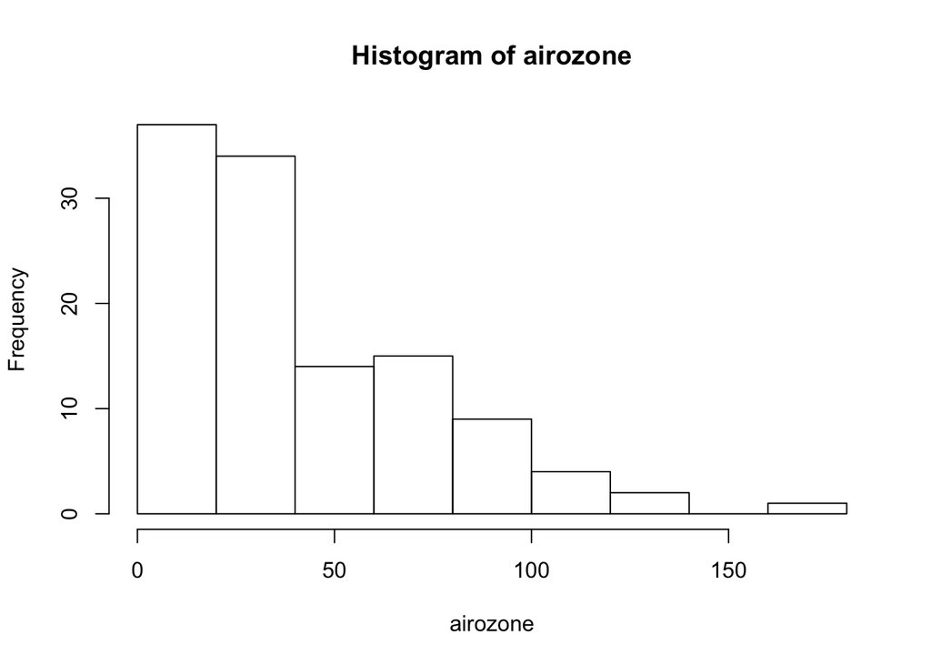

```r
hist(airozone)
```

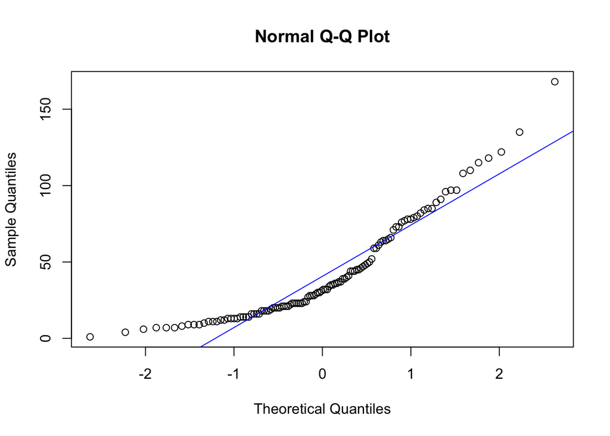

```r
qqnorm(airozone)
qqline(airozone, col="blue")
```

```r
# The balck dots are actual data. If those data are adhere/fall to the blue line then the theory is called the normal distribution. As per the current OZone data, the black dots are not falling on to the blue line, the theory is not a normal distribution.

#Reference: http://www.psychwiki.com/wiki/How_do_I_determine_whether_my_data_are_normal%3F
#Reference: http://www.r-tutor.com/r-introduction/vector/logical-index-vector
```

# Functions:

24. Make a simple function to calculate x + 6.

```r
simfun <- function(x) {
  return(x + 6)
}
```

25. Use that function add 6 to the Temp column in airquality.

```r
print(simfun(airtemp))
```

```
##   [1]  73  78  80  68  62  72  71  65  67  75  80  75  72  74  64  70  72  63
##  [19]  74  68  65  79  67  67  63  64  63  73  87  85  82  84  80  73  90  91
##  [37]  85  88  93  96  93  99  98  88  86  85  83  78  71  79  82  83  82  82
##  [55]  82  81  84  79  86  83  89  90  91  87  90  89  89  94  98  98  95  88
##  [73]  79  87  97  86  87  88  90  93  91  80  87  88  92  91  88  92  94  92
##  [91]  89  87  87  87  88  92  91  93  95  96  96  98  92  92  88  86  85  83
## [109]  85  82  84  84  83  78  81  85  87  92  94 103 100 102 100  97  98  99
## [127]  99  93  90  86  84  81  79  87  82  83  77  77  84  73  82  74  88  70
## [145]  77  87  75  69  76  83  81  82  74
```

# Packages:

26. Install the ggplot2 package.
27. Install the car package.
28. Install the ez package. (no output necessary for these three)
29. Load the car library.

```r
install.packages("ggplot2", repos = "http://cran.rstudio.com/")
install.packages("car")
```

```
## Error in contrib.url(repos, "source"): trying to use CRAN without setting a mirror
```

```r
install.packages("ez")
```

```
## Error in contrib.url(repos, "source"): trying to use CRAN without setting a mirror
```

```r
library(car)
```

# Files

30. Import the csv file provided on Canvas.

```r
#file.exists("lab_R_learning.csv")
df <- read.csv("lab_R_learning.csv")
print(df)
```

```
##    variable1 stuff2 thing3
## 1          3 cheese   TRUE
## 2          4   feta  FALSE
## 3          6  swiss   TRUE
## 4          4 cheese  FALSE
## 5          7   feta  FALSE
## 6          2  swiss   TRUE
## 7          8 cheese  FALSE
## 8          9   feta  FALSE
## 9          3  swiss   TRUE
## 10         4         FALSE
```